# Pycnogonide

Sébastien Rochette, ThinkR

2019-02-05

# 1 Exploration of “Pycnogonide” data

## 1.1 Packages

```r
library(dplyr)
library(lubridate)
library(tidyr)
library(ggplot2)
# devtools::install_github("r-spatial/sf")
library(sf)
library(raster)
library(fasterize)
library(igraph)
library(rasterVis)
library(cowplot)
library(deeptools)
# devtools::document()
# devtools::document()
# devtools::load_all(here::here(""))
```

## 1.2 Colours

```r
blue <- "#093564"
yellow <- "#efcc26"
grey <- "#675546"
```

## 1.3 Load data

```r
# load data
export_file <- system.file("data_orig/export_last.csv", package = "deeptools")
liste_photo <- system.file("data_orig/liste_photo.txt", package = "deeptools")
```

## 1.4 Prepare data

- Cleaning of species names to be easily usable
- Add user_id combining username and date of image analysis just in case a user sees the same image two times.

```r
mission2 <- readr::read_csv(export_file) %>%
  dplyr::select(-comment) %>%
  tidyr::extract(name,
          into = "datetime", regex = "_([[:digit:]]+).",
          remove = FALSE
  ) %>%
  mutate(datetime = ymd_hms(datetime, tz = "UTC")) %>%
  # clean names of species
  mutate(name_fr_clean = thinkr::clean_vec(name_fr, unique = FALSE)) %>%
  group_by(username) %>%
  mutate(
    user_id = paste(username, as.character(as.numeric(as.factor(datDeb))), sep = "-")
  ) %>%
  ungroup()
# Separate observatory dataset
mission2_MAR <- mission2 %>% filter(obs_code == "MAR")
mission2_ONC <- mission2 %>% filter(obs_code == "JDF")
```

## 1.5 Extraction of “pycnogonide”

```r
# Filter on Buccinide only
ONC2_pyc <- mission2_ONC %>%
  filter(name_fr_clean == "pycnogonide")

# Filter and transform as spatial data
ONC2_pyc_carto <- mission2_ONC %>%
  to_carto(name_fr_clean, "pycnogonide")
```

## 1.6 Exploration of annotations

### 1.6.1 Users

```r
ONC2_pyc %>%
  count(username) %>%
  arrange(desc(n))
```

```
#> # A tibble: 4 x 2
#>   username        n
#>   <chr>       <int>
#> 1 chipiok     45695
#> 2 grillus33    2277
#> 3 fetescience   807
#> 4 classe        672
```

### 1.6.2 Images

- Number of annotations by image

```r
ONC2_pyc %>%
  count(image_id) %>%
  arrange(desc(n))
```

```
#> # A tibble: 2,028 x 2
#>    image_id     n
#>       <int> <int>
#>  1    13855   180
#>  2    11725   167
#>  3    13059   165
#>  4    13373   163
#>  5    12571   158
#>  6    13510   150
#>  7    12933   146
#>  8    13578   145
#>  9    12266   135
#> 10    13405   130
#> # … with 2,018 more rows
```

- Number of users by image

```r
ONC2_pyc %>%
  group_by(image_id) %>%
  summarize(n_users = length(unique(user_id))) %>%
  arrange(desc(n_users))
```

```
#> # A tibble: 2,028 x 2
#>    image_id n_users
#>       <int>   <int>
#>  1    11425       4
#>  2    12838       4
#>  3    13988       4
#>  4    10725       3
#>  5    10784       3
#>  6    10785       3
#>  7    10874       3
#>  8    11062       3
#>  9    11083       3
#> 10    11095       3
#> # … with 2,018 more rows
```

### 1.6.3 Example: `filter_col = username, filter_val = "grillus33", image_id == "10681"`

```
#> # A tibble: 268 x 2
#>    image_id     n
#>       <int> <int>
#>  1    12738    46
#>  2    13749    46
#>  3    13059    45
#>  4    12686    42
#>  5    13836    40
#>  6    14075    40
#>  7    12954    39
#>  8    11962    38
#>  9    12024    36
#> 10    13807    34
#> # … with 258 more rows
```

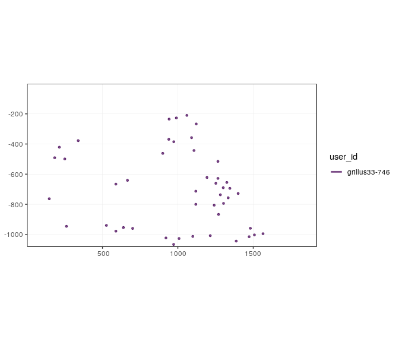

### 1.6.4 Multiple users annotations

- Example with `image_id = 11425`

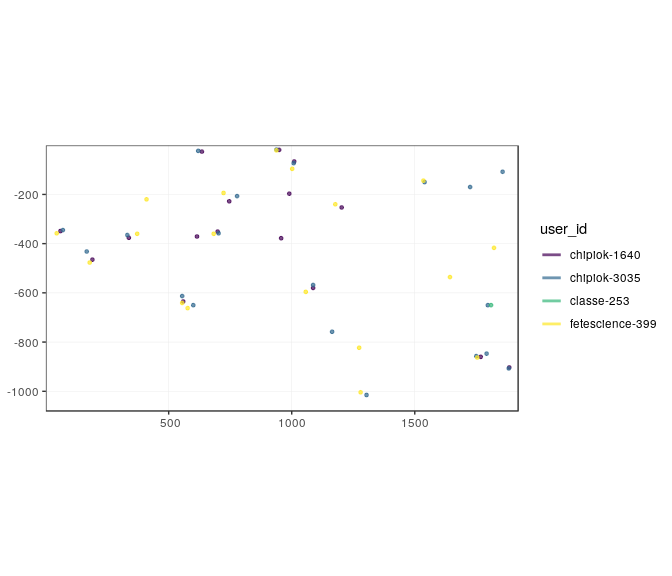

```r
gg_users_image(x = ONC2_pyc_carto,
               image_id = 11425)
```

- Comparison with buffer
- Define a buffer size for future analyses

> *It seems that precision is low for this point identification, then buffer size need to be big*

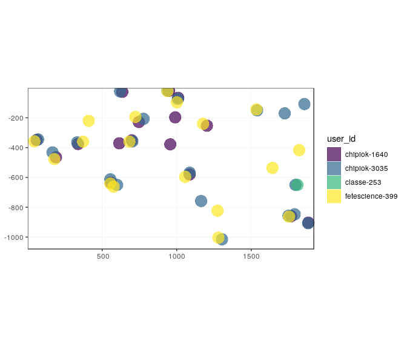

```r
gg_users_image(x = ONC2_pyc_carto,
               image_id = 11425, buffer = 40)
```

## 1.7 Find all groups

As shown for “Buccinides”, only one function is required to determine the differents groups of annotations in all images. This requires function `find_groups_in_all_images`, some time of computation and RAM available.

```r
# Chunk not evaluated in Rmd as results are saved
ONC2_pyc_carto_groups <- find_groups_in_all_images(ONC2_pyc_carto, .progress = TRUE, keep_list = FALSE, as_sf = FALSE, dist_buffer = 40)

if (!dir.exists(here::here("inst/outputs"))) {
  dir.create("inst/outputs", recursive = TRUE)
}

readr::write_rds(
  ONC2_pyc_carto_groups,
  here::here("inst/outputs", "ONC2_pyc_carto_groups.rds"),
  compress = "gz")
```

```r
outwd <- system.file("outputs", package = "deeptools")
ONC2_pyc_carto_groups <- readr::read_rds(file.path(outwd, "ONC2_pyc_carto_groups.rds"))
```

## 1.8 Calculate statistics on images

*As a reminder, a group of objects is supposed to be a unique individual.*

### 1.8.1 Number of objects per image (already known before)

```r
# Number of objects per image (already known before)
pyc_nobjects <- ONC2_pyc_carto_groups %>%
  count(image_id) %>%
  rename(n_objects = n) %>%
  count(n_objects) %>%
  arrange(desc(n)) %>%
  rename(n_images = n)

# Number of marked objects by images
pyc_nobjects
```

```
#> # A tibble: 115 x 2
#>    n_objects n_images
#>        <int>    <int>
#>  1        13      105
#>  2        12       82
#>  3        17       82
#>  4        19       81
#>  5        14       80
#>  6        16       72
#>  7        15       70
#>  8        11       68
#>  9        18       67
#> 10        20       61
#> # … with 105 more rows
```

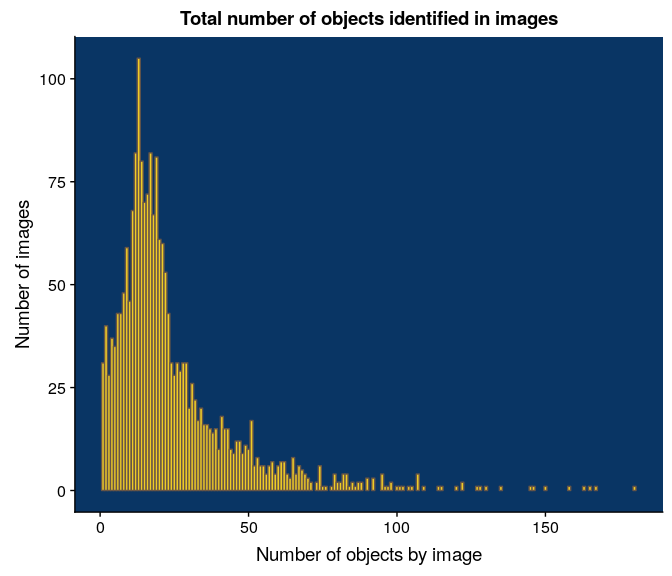

```r
# Plot
ggplot(pyc_nobjects) +
  geom_col(aes(x = n_objects, y = n_images), width = 1,
           fill = yellow, colour = grey) +
  ggtitle("Total number of objects identified in images") +
  xlab("Number of objects by image") +
  ylab("Number of images") +
  theme(panel.background = element_rect(fill = blue))
```

### 1.8.2 Statistics on groups

Calculate the number of users who marked the same individual. The `proportion` column can be used as a threshold to decide if the individual is kept. Indeed, an individual observed by only one of the users may not be a real individual.

```r
# Stats on groups
pyc_groups <- ONC2_pyc_carto_groups %>%
  group_by(image_id, group_kept) %>%
  summarise(
    n_users = n(),
    n_user_id = mean(n_user_id),
    proportion = n()/mean(n_user_id)
  ) %>%
  ungroup()

# Number of individuals ~ proportion
pyc_groups
```

```
#> # A tibble: 44,300 x 5
#>    image_id group_kept n_users n_user_id proportion
#>       <int> <chr>        <int>     <dbl>      <dbl>
#>  1    10680 1                1         1          1
#>  2    10680 10               1         1          1
#>  3    10680 11               1         1          1
#>  4    10680 12               1         1          1
#>  5    10680 13               1         1          1
#>  6    10680 14               1         1          1
#>  7    10680 15               1         1          1
#>  8    10680 16               1         1          1
#>  9    10680 17               1         1          1
#> 10    10680 18               1         1          1
#> # … with 44,290 more rows
```

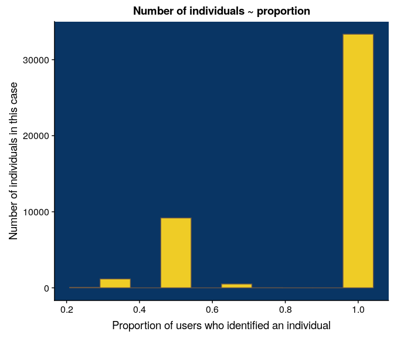

```r
# Plot
pyc_groups %>%
  ggplot() +
  geom_histogram(aes(proportion), bins = 10,
                 fill = yellow, colour = grey) +
  ggtitle("Number of individuals ~ proportion") +
  xlab("Proportion of users who identified an individual") +
  ylab("Number of individuals in this case") +
  theme(panel.background = element_rect(fill = blue))
```

### 1.8.3 Statistics on number of groups by image

Calculate the number of groups in all images.

```r
## Stats on nb groups by image
pyc_ngroups_count <- pyc_groups %>%
  group_by(image_id) %>%
  summarise(n_groups = n())

# Number of images
pyc_ngroups_count %>% count(n_groups)
```

```
#> # A tibble: 100 x 2
#>    n_groups     n
#>       <int> <int>
#>  1        1    32
#>  2        2    40
#>  3        3    28
#>  4        4    37
#>  5        5    35
#>  6        6    46
#>  7        7    45
#>  8        8    48
#>  9        9    60
#> 10       10    54
#> # … with 90 more rows
```

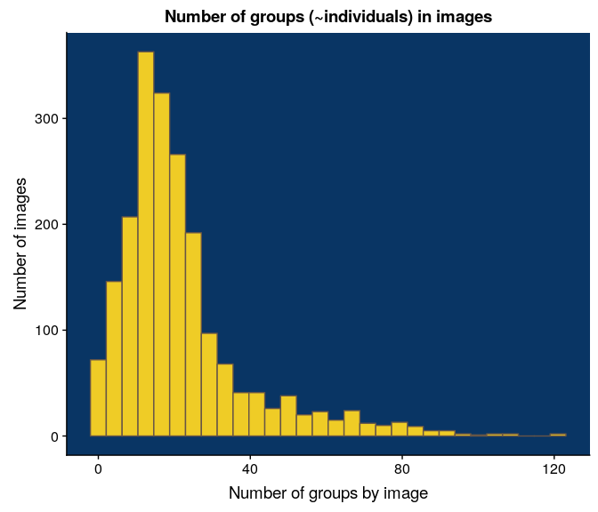

```r
# Plot
ggplot(pyc_ngroups_count) +
  geom_histogram(aes(x = n_groups), bins = 30,
                 fill = yellow, colour = grey) +
  ggtitle("Number of groups (~individuals) in images") +
  xlab("Number of groups by image") + ylab("Number of images") +
  theme(panel.background = element_rect(fill = blue))
```

If we only keep groups identified by at least half of the users, we can recalculate the number of groups by image.

```r
## Stats on nb groups by image
pyc_ngroups_count_thd <- pyc_groups %>%
  filter(proportion >= 0.5) %>%
  group_by(image_id) %>%
  summarise(n_groups = n())

# Number of images
pyc_ngroups_count_thd %>% count(n_groups)
```

```
#> # A tibble: 98 x 2
#>    n_groups     n
#>       <int> <int>
#>  1        1    33
#>  2        2    41
#>  3        3    29
#>  4        4    41
#>  5        5    37
#>  6        6    49
#>  7        7    48
#>  8        8    53
#>  9        9    64
#> 10       10    58
#> # … with 88 more rows
```

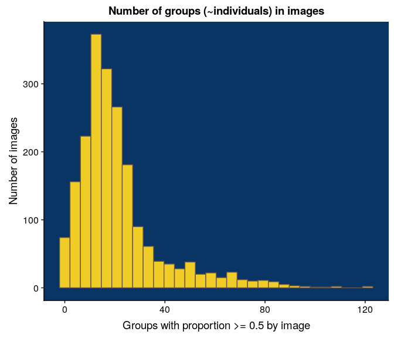

```r
# Plot
ggplot(pyc_ngroups_count_thd) +
  geom_histogram(aes(x = n_groups), bins = 30,
                 fill = yellow, colour = grey) +
  ggtitle("Number of groups (~individuals) in images") +
  xlab("Groups with proportion >= 0.5 by image") + ylab("Number of images") +
  theme(panel.background = element_rect(fill = blue))
```